# clustering

2023-11-13

## clustring:

```r
options(repos = c(CRAN = "https://cran.rstudio.com"))

# Install and load necessary libraries
install.packages("tidyverse")
install.packages("cluster")
install.packages("fastDummies")
library(tidyverse)
library(cluster)  # For clustering
library(fastDummies)  # For one-hot encoding
```

```r
# Load the data
data <- read.csv("credit_customers.csv")

# Convert numeric columns to numeric types (if they are not already)
numeric_columns <- c("duration", "credit_amount", "installment_commitment", "age", "existing_credits", "num_dependents")
data[numeric_columns] <- lapply(data[numeric_columns], as.numeric)

# One-hot encode categorical variables
categorical_columns <- c("checking_status", "credit_history", "purpose", "savings_status", "employment",
                         "personal_status", "other_parties", "property_magnitude", "other_payment_plans",
                         "housing", "job", "own_telephone", "foreign_worker", "class")
data <- dummy_cols(data, select_columns = categorical_columns)
```

```r
# Remove the original categorical columns after encoding
data <- data %>% select(-all_of(categorical_columns))
```

```r
# Handle missing values (if any)
data <- na.omit(data)

# Z-score Standardization
# Apply standardization only to numeric columns
data_standardized <- data
data[numeric_columns] <- scale(data[numeric_columns])
# Assuming you have already standardized your data and it is stored in `data_standardized`

# Step 2: Perform PCA
pca_result <- prcomp(data_standardized, center = FALSE, scale. = FALSE)  # Data is already standardized

# Step 3: Analyze PCA Results
# View summary of PCA results
print(summary(pca_result))
```

```
## Importance of components:
##                         PC1      PC2     PC3   PC4   PC5    PC6    PC7    PC8
## Standard deviation     4322 26.86176 9.87369 1.467 1.061 0.8317 0.8146 0.7239
## Proportion of Variance    1  0.00004 0.00001 0.000 0.000 0.0000 0.0000 0.0000
## Cumulative Proportion     1  0.99999 1.00000 1.000 1.000 1.0000 1.0000 1.0000
##                           PC9  PC10   PC11   PC12   PC13   PC14   PC15   PC16
## Standard deviation     0.6551 0.604 0.5935 0.5733 0.5439 0.5404 0.5315 0.5113
## Proportion of Variance 0.0000 0.000 0.0000 0.0000 0.0000 0.0000 0.0000 0.0000
## Cumulative Proportion  1.0000 1.000 1.0000 1.0000 1.0000 1.0000 1.0000 1.0000
##                          PC17   PC18   PC19   PC20   PC21   PC22   PC23   PC24
## Standard deviation     0.4914 0.4881 0.4628 0.4564 0.4333 0.4258 0.4038 0.3832
## Proportion of Variance 0.0000 0.0000 0.0000 0.0000 0.0000 0.0000 0.0000 0.0000
## Cumulative Proportion  1.0000 1.0000 1.0000 1.0000 1.0000 1.0000 1.0000 1.0000
##                          PC25   PC26   PC27   PC28   PC29  PC30   PC31  PC32
## Standard deviation     0.3754 0.3635 0.3548 0.3472 0.3425 0.332 0.3185 0.289
## Proportion of Variance 0.0000 0.0000 0.0000 0.0000 0.0000 0.000 0.0000 0.000
## Cumulative Proportion  1.0000 1.0000 1.0000 1.0000 1.0000 1.000 1.0000 1.000
##                          PC33   PC34  PC35   PC36   PC37   PC38   PC39   PC40
## Standard deviation     0.2784 0.2695 0.258 0.2549 0.2414 0.2357 0.2337 0.2251
## Proportion of Variance 0.0000 0.0000 0.000 0.0000 0.0000 0.0000 0.0000 0.0000
## Cumulative Proportion  1.0000 1.0000 1.000 1.0000 1.0000 1.0000 1.0000 1.0000
##                          PC41   PC42   PC43   PC44   PC45   PC46   PC47   PC48
## Standard deviation     0.2214 0.2106 0.2013 0.1876 0.1709 0.1531 0.1378 0.1183
## Proportion of Variance 0.0000 0.0000 0.0000 0.0000 0.0000 0.0000 0.0000 0.0000
## Cumulative Proportion  1.0000 1.0000 1.0000 1.0000 1.0000 1.0000 1.0000 1.0000
##                          PC49    PC50      PC51      PC52      PC53      PC54
## Standard deviation     0.1032 0.09393 1.919e-12 3.714e-13 3.714e-13 3.714e-13
## Proportion of Variance 0.0000 0.00000 0.000e+00 0.000e+00 0.000e+00 0.000e+00
## Cumulative Proportion  1.0000 1.00000 1.000e+00 1.000e+00 1.000e+00 1.000e+00
##                             PC55      PC56      PC57      PC58      PC59
## Standard deviation     3.714e-13 3.714e-13 3.714e-13 3.714e-13 3.714e-13
## Proportion of Variance 0.000e+00 0.000e+00 0.000e+00 0.000e+00 0.000e+00
## Cumulative Proportion  1.000e+00 1.000e+00 1.000e+00 1.000e+00 1.000e+00
##                             PC60      PC61      PC62      PC63
## Standard deviation     3.714e-13 3.714e-13 3.714e-13 3.714e-13
## Proportion of Variance 0.000e+00 0.000e+00 0.000e+00 0.000e+00
## Cumulative Proportion  1.000e+00 1.000e+00 1.000e+00 1.000e+00
```

```r
# Decide how many principal components to keep based on variance explained
# For example, you might decide to keep components that explain 80% of the variance
# This is just an example, adjust based on your analysis
cum_var_explained <- cumsum(pca_result$sdev^2 / sum(pca_result$sdev^2))
num_components <- which(cum_var_explained >= 0.8)[1]

# Step 4: Use Principal Components for Clustering
# Select the number of principal components to use
data_pca <- pca_result$x[, 1:num_components]

loadings <- pca_result$rotation[, 1]
print(loadings)
```

```
##                                      duration
##                                 -4.803096e-03
##                                 credit_amount
##                                 -9.999683e-01
##                        installment_commitment
##                                 -4.753056e-04
##                               residence_since
##                                 -5.035540e-04
##                                           age
##                                 -6.287492e-03
##                              existing_credits
##                                 -2.484625e-04
##                                num_dependents
##                                 -2.034096e-04
##                            checking_status_<0
##                                 -4.662222e-05
##                         checking_status_>=200
##                                 -7.352188e-06
##                      checking_status_0<=X<200
##                                 -5.517411e-05
##                   checking_status_no checking
##                                 -6.615155e-05
##                       credit_history_all paid
##                                 -8.783029e-06
## credit_history_critical/other existing credit
##                                 -4.848660e-05
##             credit_history_delayed previously
##                                 -2.028961e-05
##                  credit_history_existing paid
##                                 -8.636841e-05
##            credit_history_no credits/all paid
##                                 -1.137243e-05
##                              purpose_business
##                                 -2.161332e-05
##                    purpose_domestic appliance
##                                 -9.633940e-07
##                             purpose_education
##                                 -8.521643e-06
##                   purpose_furniture/equipment
##                                 -2.974796e-05
```

[output cut: 71 more lines]

```
##                                 -3.236414e-06
##                        job_unskilled resident
##                                 -2.527848e-05
##                            own_telephone_none
##                                 -8.393064e-05
##                             own_telephone_yes
##                                 -9.136943e-05
##                             foreign_worker_no
##                                 -5.057797e-06
##                            foreign_worker_yes
##                                 -1.702423e-04
##                                     class_bad
##                                 -6.330993e-05
##                                    class_good
##                                 -1.119901e-04
```

```r
data_pca <- pca_result$x[, 1]
k2_pca <- kmeans(data_pca, centers = 2, nstart = 25)

data_for_plot <- cbind(data_pca, rep(0, length(data_pca)))
data_pca_df <- as.data.frame(data_pca)
# Extracting the first three principal components
data_pca <- pca_result$x[, 1:3]

# Convert the PCA results to a data frame
data_pca_df <- as.data.frame(data_pca)
```

```r
# Load necessary library for visualization
library(factoextra)
```

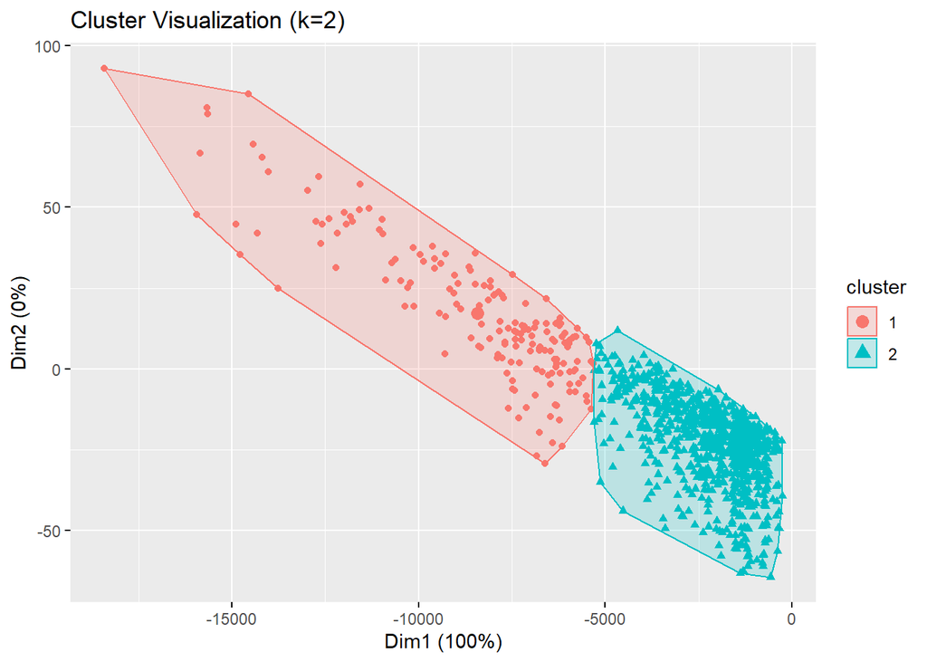

```r
# Clustering and plotting for k = 2, 3, and 4
set.seed(123)  # For reproducibility

# Clustering for k = 2
k2 <- kmeans(data_pca_df, centers = 2, nstart = 25)
fviz_cluster(k2, data = data_pca_df, geom = "point",
             stand = FALSE, frame = FALSE,
             main = "Cluster Visualization (k=2)")
```

```r
print(paste("Total WSS for k=2:", k2$tot.withinss))
```

```
## [1] "Total WSS for k=2: 2405437340.30842"
```

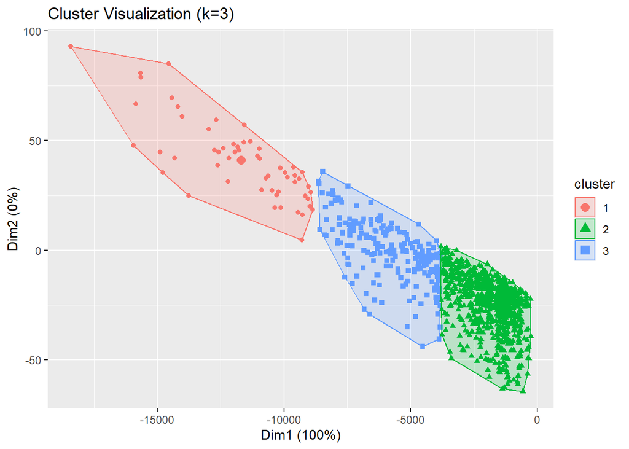

```r
# Clustering for k = 3
k3 <- kmeans(data_pca_df, centers = 3, nstart = 25)
fviz_cluster(k3, data = data_pca_df, geom = "point",
             stand = FALSE, frame = FALSE,
             main = "Cluster Visualization (k=3)")
```

```r
print(paste("Total WSS for k=3:", k3$tot.withinss))
```

```
## [1] "Total WSS for k=3: 1278199845.95002"
```

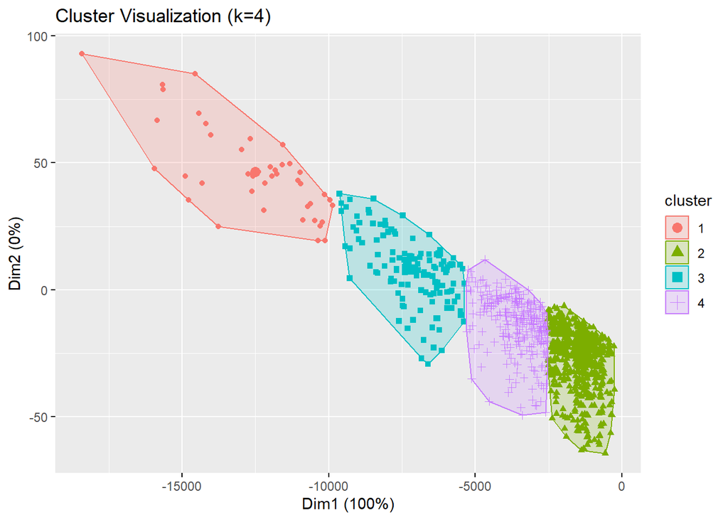

```r
# Clustering for k = 4
k4 <- kmeans(data_pca_df, centers = 4, nstart = 25)
fviz_cluster(k4, data = data_pca_df, geom = "point",
             stand = FALSE, frame = FALSE,
             main = "Cluster Visualization (k=4)")
```

```r
print(paste("Total WSS for k=4:", k4$tot.withinss))
```

```
## [1] "Total WSS for k=4: 649852654.52308"
```

1. **Load Data:** Reads a CSV file named “credit_customers.csv” into the variable ‘data.’
2. **Numeric Conversion:** Converts specific columns (duration, credit_amount, installment_commitment, age, existing_credits, num_dependents) to numeric types if they are not already.
3. **One-Hot Encoding:** Performs one-hot encoding on categorical variables listed in ‘categorical_columns,’ creating dummy variables for each category. This expands the dataset with binary columns representing each category.
4. **Remove Original Categorical Columns:** Removes the original categorical columns after one-hot encoding to avoid redundancy.
5. **Handle Missing Values:** Uses `na.omit` to remove rows with missing values from the dataset.

In short, the code prepares the dataset for analysis by converting numeric types, one-hot encoding categorical variables, and handling missing values.

```r
set.seed(123)  # For reproducibility

# Perform k-means clustering with different K values
k2 <- kmeans(data, centers = 2, nstart = 25)
k3 <- kmeans(data, centers = 3, nstart = 25)
k4 <- kmeans(data, centers = 4, nstart = 25)

# Print cluster centers for a quick check
print(k2$centers)
```

```
##     duration credit_amount installment_commitment residence_since         age
## 1  1.2116045     1.2661377            -0.20710130        2.926641  0.11695763
## 2 -0.4234893    -0.4425502             0.07238763        2.816464 -0.04087993
##   existing_credits num_dependents checking_status_<0 checking_status_>=200
## 1       0.15097000     0.13707582          0.2895753            0.02316602
## 2      -0.05276819    -0.04791179          0.2685560            0.07692308
##   checking_status_0<=X<200 checking_status_no checking credit_history_all paid
## 1                0.3552124                   0.3320463              0.06563707
## 2                0.2388664                   0.4156545              0.04318489
##   credit_history_critical/other existing credit
## 1                                     0.2702703
## 2                                     0.3009447
##   credit_history_delayed previously credit_history_existing paid
## 1                        0.15444015                    0.4208494
## 2                        0.06477733                    0.5681511
##   credit_history_no credits/all paid purpose_business
## 1                         0.08880309       0.17374517
## 2                         0.02294197       0.07017544
##   purpose_domestic appliance purpose_education purpose_furniture/equipment
## 1                0.007722008        0.06177606                   0.1351351
## 2                0.013495277        0.04588394                   0.1970310
##   purpose_new car purpose_other purpose_radio/tv purpose_repairs
## 1       0.1660232   0.030888031        0.1776062      0.01930502
## 2       0.2577598   0.005398111        0.3157895      0.02294197
##   purpose_retraining purpose_used car savings_status_<100 savings_status_>=1000
## 1         0.00000000       0.22779923           0.5907336            0.03088803
## 2         0.01214575       0.05937922           0.6072874            0.05398111
##   savings_status_100<=X<500 savings_status_500<=X<1000
## 1                 0.1042471                 0.02702703
## 2                 0.1025641                 0.07557355
##   savings_status_no known savings employment_<1 employment_>=7
## 1                       0.2471042     0.1196911      0.2586873
## 2                       0.1605938     0.1902834      0.2510121
##   employment_1<=X<4 employment_4<=X<7 employment_unemployed
## 1         0.3166023         0.2084942            0.09652510
## 2         0.3468286         0.1619433            0.04993252
##   personal_status_female div/dep/mar personal_status_male div/sep
## 1                          0.2277992                   0.05405405
## 2                          0.3387314                   0.04858300
##   personal_status_male mar/wid personal_status_male single
```

[output cut: 11 more lines]

```
##   other_payment_plans_bank other_payment_plans_none other_payment_plans_stores
## 1                0.1621622                0.7722008                 0.06563707
## 2                0.1309042                0.8286100                 0.04048583
##   housing_for free housing_own housing_rent job_high qualif/self emp/mgmt
## 1       0.23166023   0.6447876    0.1235521                    0.31660232
## 2       0.06477733   0.7368421    0.1983806                    0.08906883
##   job_skilled job_unemp/unskilled non res job_unskilled resident
## 1   0.5791506                  0.01544402             0.08880309
## 2   0.6477733                  0.02429150             0.23886640
##   own_telephone_none own_telephone_yes foreign_worker_no foreign_worker_yes
## 1          0.3745174         0.6254826        0.01158301          0.9884170
## 2          0.6734143         0.3265857        0.04588394          0.9541161
##   class_bad class_good
## 1 0.4478764  0.5521236
## 2 0.2483131  0.7516869
```

```r
print(k3$centers)
```

```
##     duration credit_amount installment_commitment residence_since         age
## 1 -0.3135906    -0.3096579             0.19836627        3.539548  0.79060902
## 2  1.5161562     1.6689695            -0.30847278        2.837209 -0.04493145
## 3 -0.3159658    -0.3743541            -0.03621169        2.329114 -0.57415060
##   existing_credits num_dependents checking_status_<0 checking_status_>=200
## 1       0.43484835     0.31307936          0.2457627           0.067796610
## 2       0.04021878     0.08574353          0.3139535           0.005813953
## 3      -0.33935431    -0.26493245          0.2805907           0.080168776
##   checking_status_0<=X<200 checking_status_no checking credit_history_all paid
## 1                0.2203390                   0.4661017              0.04802260
## 2                0.3662791                   0.3139535              0.05813953
## 3                0.2700422                   0.3691983              0.04641350
##   credit_history_critical/other existing credit
## 1                                     0.4802260
## 2                                     0.2441860
```

[output cut: 73 more lines]

```r
print(k4$centers)
```

```
##     duration credit_amount installment_commitment residence_since         age
## 1  1.5354163     1.7782619            -0.33224987        2.771242 -0.07212976
## 2 -0.2621779    -0.3225490             0.29943720        3.657795  0.89760294
## 3 -0.3045267    -0.3761056            -0.01428999        2.352941 -0.60190092
## 4 -0.2208810    -0.1479227            -0.15212377        2.950704  0.28877807
##   existing_credits num_dependents checking_status_<0 checking_status_>=200
## 1       0.03087763     -0.1934146          0.2614379           0.006535948
## 2       0.34200850     -0.4280754          0.2091255           0.068441065
## 3      -0.29724670     -0.4280754          0.2918552           0.079185520
## 4       0.25852484      2.3337012          0.3521127           0.063380282
##   checking_status_0<=X<200 checking_status_no checking credit_history_all paid
## 1                0.3921569                   0.3398693              0.05882353
## 2                0.2357414                   0.4866920              0.03422053
## 3                0.2714932                   0.3574661              0.04072398
## 4                0.1901408                   0.3943662              0.09154930
```

[output cut: 95 more lines]

**### Cluster Centers:**

#### K = 2:

- **Cluster 1:**
  - High values in `duration`, `credit_amount`, `residence_since`, and `age`.
  - Higher `existing_credits` and `num_dependents`.
  - More likely to have a checking account status of `<0` and less likely to be `critical/other existing credit` in credit history.
  - Higher chance of being a `bad` credit class.
- **Cluster 2:**
  - Lower values in `duration`, `credit_amount`, `residence_since`, and `age`.
  - Lower `existing_credits` and `num_dependents`.
  - More likely to have a checking account status of `no` and possibly `critical/other existing credit` in credit history.
  - Higher chance of being a `good` credit class.

#### K = 3:

- Similar interpretations for each cluster, but now you have an additional cluster, indicating finer granularity.

#### K = 4:

- Similar interpretation but with further subdivisions.

### Comments:

- K-means clustering is an unsupervised learning technique, and the interpretability of the clusters depends on the context of your data and the features involved.
- The choice of the number of clusters (k) is subjective and often involves domain knowledge or experimentation.
- The clustering results can be further validated using other techniques or by assessing the coherence and separation of clusters.

```r
# Silhouette width for each K
sil_width2 <- silhouette(k2$cluster, dist(data))
sil_width3 <- silhouette(k3$cluster, dist(data))
sil_width4 <- silhouette(k4$cluster, dist(data))

# Calculate average silhouette width for each K
avg_sil_width2 <- mean(sil_width2[, "sil_width"])
avg_sil_width3 <- mean(sil_width3[, "sil_width"])
avg_sil_width4 <- mean(sil_width4[, "sil_width"])
```

```r
# Print average silhouette widths
print(avg_sil_width2)
```

```
## [1] 0.1177079
```

```r
print(avg_sil_width3)
```

```
## [1] 0.09012181
```

```r
print(avg_sil_width4)
```

```
## [1] 0.0959719
```

```r
# Total within-cluster sum of squares for each K
total_withinss2 <- k2$tot.withinss
total_withinss3 <- k3$tot.withinss
total_withinss4 <- k4$tot.withinss

# Print total within-cluster sum of squares
print(total_withinss2)
```

```
## [1] 13212.06
```

```r
print(total_withinss3)
```

```
## [1] 12223.55
```

```r
print(total_withinss4)
```

```
## [1] 11461.63
```

```r
# BCubed precision and recall (requires additional computations, shown here as placeholders)
# bcubed_precision2 <- ...
# bcubed_recall2 <- ...
# Similarly for k3 and k4
```

The output includes evaluation metrics for clustering:

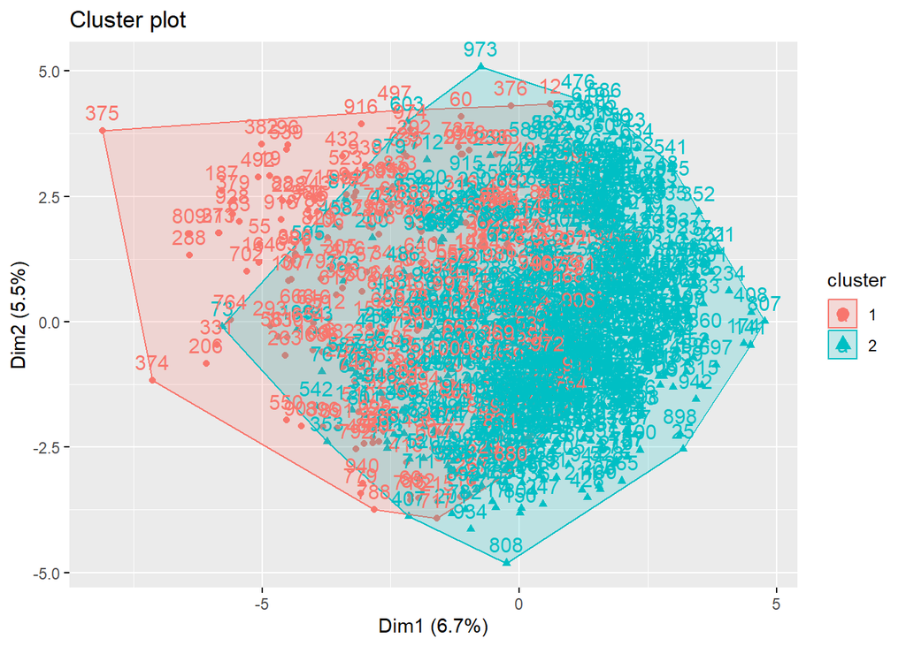

```r
# Load necessary library for visualization
library(factoextra)

# Plot for K=2
fviz_cluster(k2, data = data)
```

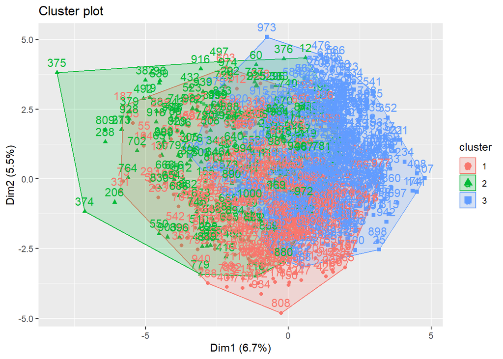

```r
# Plot for K=3
fviz_cluster(k3, data = data)
```

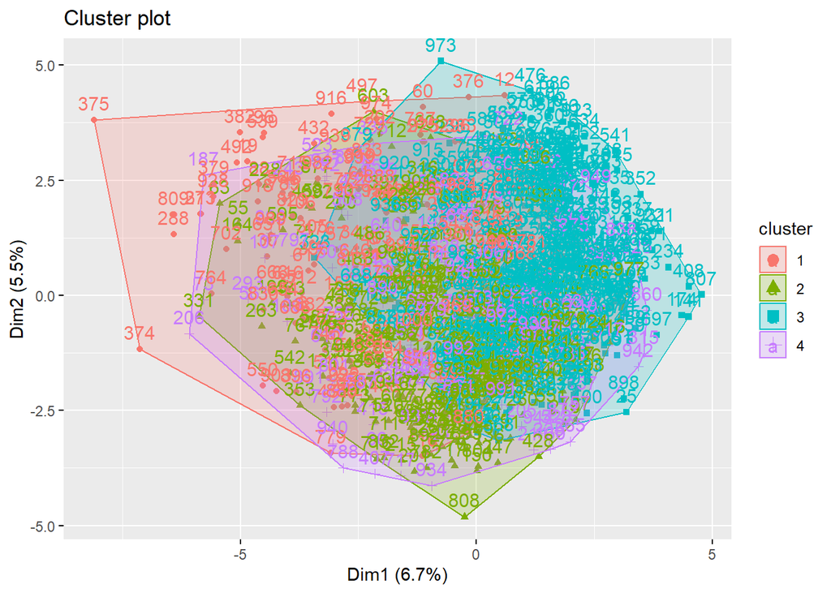

```r
# Plot for K=4
fviz_cluster(k4, data = data)
```

  Increasing overlap in clusters with higher K suggests that the algorithm may be creating more detailed and potentially noise-driven clusters. It’s crucial to balance model metrics and consider the meaningful interpretation of clusters. Reevaluate K using methods like the elbow method and silhouette analysis and incorporate domain knowledge for context.

```r
if (!require(fpc)) {
  install.packages("fpc")
}
```

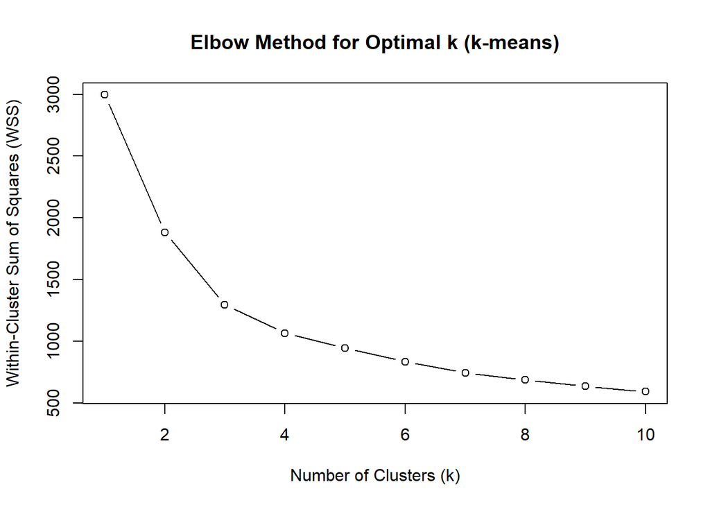

```r
library(cluster)
library(fpc)

# Load the data
data <- read.csv("credit_customers.csv")

# Specify the numeric and categorical attributes
numeric_attributes <- c("duration", "credit_amount", "age")
categorical_attributes <- setdiff(names(data), c("duration", "credit_amount", "age", "class"))

# Extract the relevant columns
numeric_data <- data[, numeric_attributes]
categorical_data <- data[, categorical_attributes]

# Check and convert columns in categorical_data to factors if needed
for (col in names(categorical_data)) {
  if (!is.factor(categorical_data[[col]]) && !is.numeric(categorical_data[[col]])) {
    categorical_data[[col]] <- as.factor(categorical_data[[col]])
  }
}

# Normalize numeric data (optional but often recommended)
normalized_numeric_data <- scale(numeric_data)

# Elbow method for determining the optimal number of clusters (k-means)
wss <- numeric(length = 10)
for (k in 1:10) {
  kmeans_model <- kmeans(normalized_numeric_data, centers = k, nstart = 10)
  wss[k] <- sum(kmeans_model$withinss)
}

# Plot the Elbow method graph with adjusted margins
par(mar = c(5, 4, 4, 2) + 0.1)
plot(1:10, wss, type = "b", main = "Elbow Method for Optimal k (k-means)",
     xlab = "Number of Clusters (k)", ylab = "Within-Cluster Sum of Squares (WSS)")
```

```r
# Choose three different sizes of K based on the Elbow plot
optimal_k <- which.min(wss)
k_values <- c(optimal_k, optimal_k - 1, optimal_k + 1)

# Perform k-medoids clustering on categorical data
dissimilarity_matrix <- daisy(categorical_data, metric = "gower")
kmedoids_model <- pam(dissimilarity_matrix, k = 3)

# Print the k-medoids clustering results
cat("\nK-Medoids Clustering Results:\n")
```

```
##
## K-Medoids Clustering Results:
```

```r
print(kmedoids_model)
```

```
## Medoids:
##       ID
## [1,] 892 892
## [2,] 309 309
## [3,]  53  53
## Clustering vector:
##    [1] 1 2 3 2 3 3 3 3 3 3 2 2 3 1 2 3 1 3 2 3 1 3 3 2 3 2 1 2 3 1 2 3 3 1 2 3 1
##   [38] 3 3 3 3 3 2 1 1 1 3 2 3 3 2 1 3 3 1 3 3 3 3 1 2 1 1 3 1 1 3 2 3 3 3 1 1 2
##   [75] 1 1 3 3 3 2 3 1 2 2 3 1 2 2 3 3 1 1 1 1 1 1 3 3 1 1 2 3 3 1 1 1 1 3 2 2 3
##  [112] 2 2 1 3 1 1 2 2 1 2 1 3 1 2 3 3 3 1 2 2 1 3 3 2 1 3 3 1 3 2 2 3 3 1 3 1 1
##  [149] 3 1 1 3 3 2 1 2 1 3 3 3 1 3 1 2 3 3 2 2 2 1 1 2 2 3 3 2 3 1 3 1 3 2 3 1 1
##  [186] 3 2 1 3 2 3 2 3 3 3 1 1 2 1 1 1 2 3 2 1 1 1 3 3 3 3 1 1 1 1 2 3 3 2 3 2 2
##  [223] 3 1 3 3 3 1 3 3 3 3 3 2 3 3 3 3 3 3 3 3 1 2 2 3 1 3 2 2 2 2 2 3 3 3 3 3 3
##  [260] 1 2 3 1 1 1 3 1 3 1 3 3 1 1 2 3 3 3 2 2 3 1 3 3 1 1 2 3 1 2 2 3 2 1 1 1 2
##  [297] 3 3 2 1 2 3 3 1 3 2 2 1 2 2 2 3 2 3 3 1 2 2 3 2 3 3 3 3 2 2 1 1 3 3 1 2 2
```

[output cut: 26 more lines]

```r
# Evaluate clustering using Silhouette coefficient for k-medoids
silhouette_kmedoids <- silhouette(kmedoids_model$cluster, dissimilarity_matrix)
cat("\nSilhouette Coefficient for K-Medoids Clustering:\n")
```

```
##
## Silhouette Coefficient for K-Medoids Clustering:
```

```r
print(silhouette_kmedoids)
```

```
##         cluster neighbor     sil_width
##    [1,]       1        3  0.2280045039
##    [2,]       2        3  0.0594015132
##    [3,]       3        1  0.0469165170
##    [4,]       2        3 -0.0160528105
##    [5,]       3        1  0.0208362677
##    [6,]       3        1 -0.0129747939
##    [7,]       3        1  0.0403588370
##    [8,]       3        2  0.0641343536
##    [9,]       3        2  0.0115605930
##   [10,]       3        1  0.0042428994
##   [11,]       2        3  0.0775023638
##   [12,]       2        3  0.1475124585
##   [13,]       3        2  0.0095539335
##   [14,]       1        3  0.1026023157
```

[output cut: 992 more lines]

```r
# Evaluate BCubed precision and recall for k-medoids
bcubed_kmedoids <- cluster.stats(dissimilarity_matrix, kmedoids_model$cluster)$bcubed
cat("\nBCubed Precision and Recall for K-Medoids Clustering:\n")
```

```
##
## BCubed Precision and Recall for K-Medoids Clustering:
```

```r
print(bcubed_kmedoids)
```

[output not shown]

The output shows the results of k-medoids clustering:

- **Medoids:** Representative data points for each cluster.
- **Clustering vector:** Assigns each data point to a cluster.
- **Objective function:** The optimization criterion for clustering.

The clusters are formed based on the dissimilarity matrix. Each data point is assigned to the medoid (representative) that minimizes the dissimilarity within its cluster.

The “Objective function” values represent the quality of the clustering, with lower values indicating better-defined clusters. The “build” and “swap” values show the contributions to the objective function during the build and swap phases of the algorithm.

Overall, the k-medoids algorithm has divided your data into three clusters, and the medoids represent central points within each cluster.

Summary:

findings After working with both Classification (Supervised) and Clustering (Unsupervised) we came to the conclusion that using Classification is the better option to deal with our dataset since we decided from the begining that we wanted to study weather someone will hae a bad or a good credit based on certain attributes, we find that superviseed learning where the class label was known gave better results with its evaluation metrics and it was easier to compute since the majority of our dataset attributes was nominal (since we needed to normlize the data first and select certain attributes to avoid overlapping).